# Analysis

This section will process the E. coli datasets

We'll first need a function to extract the true network for inclusion in our aggregated tables.

```r
library(ENA)
set.seed(123)
```

```r
truthToMat <- function(IDs, truthList) {
    truth <- matrix(0, ncol = length(IDs), nrow = length(IDs))
    rownames(truth) <- IDs
    colnames(truth) <- IDs
    diag(truth) <- 1
    for (i in 1:dim(truthList)[1]) {
        s <- truthList[i, ]$Source
        t <- truthList[i, ]$Target
        truth[which(IDs == s), which(IDs == t)] <- 1
    }
    truth <- symmetricize(truth, "max")
    return(truth)
}
truthList <- read.csv("../data/ecoli/ecoli_truth.csv")
truthList <- truthList[, c(3, 5)]
colnames(truthList) <- c("Source", "Target")
filteredGenes <- union(truthList$Source, truthList$Target)
truth <- truthToMat(filteredGenes, truthList)
```

Now we can start loading the E. coli expression data.

```r
ecoli <- read.csv("../data/ecoli/filtered.csv", row.names = 1)
ecoli2 <- read.csv("../data/ecoli/GSE33147.csv", row.names = 1)
ecoli3 <- read.csv("../data/ecoli/BC clean.csv", row.names = 1)
```

The original ecoli file we considered had already been sampled to select only specific genes, thus, it will have many fewer genes than the other datasets. We'll want to filter the genes from the other two datasets only to include those genes which are contained in all of the datasets. We'll also need to make sure the gene names are all lower case, so we can more easily match them.

```r
rownames(ecoli) <- tolower(rownames(ecoli))
rownames(ecoli2) <- tolower(rownames(ecoli2))
rownames(ecoli3) <- tolower(rownames(ecoli3))

ecoli <- ecoli[rownames(ecoli) %in% filteredGenes, ]
ecoli2 <- ecoli2[rownames(ecoli2) %in% filteredGenes, ]
ecoli3 <- ecoli3[rownames(ecoli3) %in% filteredGenes, ]

# remove any gene which has no information in any sample. Space can't
# support this.
ecoli3 <- ecoli3[!apply(ecoli3, 1, function(x) all(is.na(x))), ]

# set the rest to ~0. Need to add some variance of Space will complain if
# we permute the samples such that all of the samples in some run are
# equal.
ecoli3[is.na(ecoli3)] <- rnorm(sum(is.na(ecoli3)), sd = 0.01)
```

We can now rebuild the networks on each dataset independently.

```r
library(snow)
invisible(capture.output(cluster <- makeCluster(mpi.universe.size() -
    1, type = "MPI")))
sp <- bootstrap(ecoli, "buildSpace", cluster = cluster, iterations = 140)
wg <- buildWgcna(ecoli)
wg <- wg[upper.tri(wg)]
gn <- buildGenenet(ecoli)
```

```
## Estimating optimal shrinkage intensity lambda (correlation matrix): 0.0256
```

```r
gn <- gn[upper.tri(gn)]

joint1 <- ena(cbind(gn, wg, sp[, 3]))
joint1 <- data.frame(sp, wg, gn, joint1)
colnames(joint1) <- c("Source", "Dest", "BootstrappedSpace", "WGCNA",
    "GeneNet", "ENA")
# Since this graph is undirected, for consistency, make Source always
# smaller than Dest
allGenes <- union(joint1$Source, joint1$Dest)
joint1$Source <- factor(joint1$Source, levels = allGenes)
joint1$Dest <- factor(joint1$Dest, levels = allGenes)
joint1[as.character(joint1$Source) > as.character(joint1$Dest), 1:2] <- joint1[as.character(joint1$Source) >
    as.character(joint1$Dest), 2:1]


## Process second dataset

sp <- bootstrap(ecoli2, "buildSpace", cluster = cluster, iterations = 140)
wg <- buildWgcna(ecoli2)
wg <- wg[upper.tri(wg)]
gn <- buildGenenet(ecoli2)
```

```
## Estimating optimal shrinkage intensity lambda (correlation matrix): 0.1216
```

```r
gn <- gn[upper.tri(gn)]

joint2 <- ena(cbind(gn, wg, sp[, 3]))
joint2 <- data.frame(sp, wg, gn, joint2)
colnames(joint2) <- c("Source", "Dest", "BootstrappedSpace", "WGCNA",
    "GeneNet", "ENA")
# Since this graph is undirected, for consistency, make Source always
# smaller than Dest
allGenes <- union(joint2$Source, joint2$Dest)
joint2$Source <- factor(joint2$Source, levels = allGenes)
joint2$Dest <- factor(joint2$Dest, levels = allGenes)
joint2[as.character(joint2$Source) > as.character(joint2$Dest), 1:2] <- joint2[as.character(joint2$Source) >
    as.character(joint2$Dest), 2:1]


## Process thid dataset

sp <- bootstrap(ecoli3, "buildSpace", cluster = cluster, iterations = 140)
wg <- buildWgcna(ecoli3)
wg <- wg[upper.tri(wg)]
gn <- buildGenenet(ecoli3)
```

```
## Estimating optimal shrinkage intensity lambda (correlation matrix): 0.1372
```

```r
gn <- gn[upper.tri(gn)]

joint3 <- ena(cbind(gn, wg, sp[, 3]))
joint3 <- data.frame(sp, wg, gn, joint3)
colnames(joint3) <- c("Source", "Dest", "BootstrappedSpace", "WGCNA",
    "GeneNet", "ENA")
# Since this graph is undirected, for consistency, make Source always
# smaller than Dest
allGenes <- union(joint3$Source, joint3$Dest)
joint3$Source <- factor(joint3$Source, levels = allGenes)
joint3$Dest <- factor(joint3$Dest, levels = allGenes)
joint3[as.character(joint3$Source) > as.character(joint3$Dest), 1:2] <- joint3[as.character(joint3$Source) >
    as.character(joint3$Dest), 2:1]

save(joint1, joint2, joint3, file = "JointEcoli.Rda")

stopCluster(cluster)
```

```
## [1] 1
```

### Analysis

Now that we have the results from each dataset, we can analyze each one separately before merging them.

```r
library(ROCR)
```

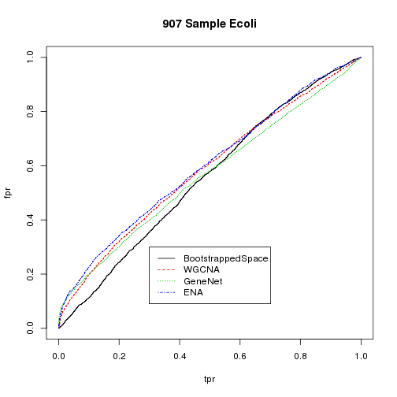

```r
plotPerformance <- function(thisJoint, title = "") {
    aucs <- list()
    if (!("Truth" %in% colnames(thisJoint))) {
        thisFilteredGenes <- union(thisJoint$Source, thisJoint$Dest)

        # select only those truth columns which exist in this network
        truthIndexes <- which(rownames(truth) %in% thisFilteredGenes)
        thisTruth <- truth[truthIndexes, truthIndexes]

        # get addressing/truth based only on this network.
        addressing <- getTableAddressing(colnames(thisTruth), thisTruth)
        thisJoint <- merge(addressing, thisJoint, by = c("Source", "Dest"),
            all.x = TRUE)
    }

    plot(0, xlim = c(0, 1), ylim = c(0, 1), type = "n", xlab = "tpr", ylab = "fpr",
        main = title)

    for (i in 4:ncol(thisJoint)) {
        pred <- prediction(thisJoint[, i], thisJoint$Truth)
        perf <- performance(pred, "tpr", "fpr")
        aucs[colnames(thisJoint)[i]] <- performance(pred, "auc")@y.values[[1]]
        lines(perf@x.values[[1]], perf@y.values[[1]], type = "l", lwd = 1, col = i -
            3, lty = i - 3)
    }

    legend(colnames(thisJoint[4:ncol(thisJoint)]), x = 0.3, y = 0.3, col = 1:(ncol(thisJoint) -
        3), lty = 1:(ncol(thisJoint) - 3), lwd = 1)
    return(aucs)
}
auc1 <- plotPerformance(joint1, "907 Sample Ecoli")
```

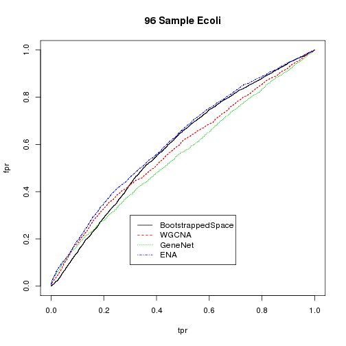

```r
auc2 <- plotPerformance(joint2, "96 Sample Ecoli")
```

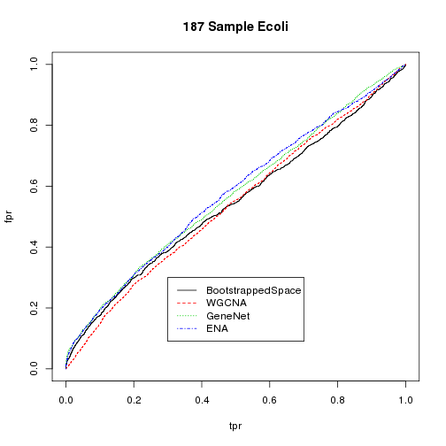

```r
auc3 <- plotPerformance(joint3, "187 Sample Ecoli")
```

### Merge Datasets

We can now look at merging the three Joint networks to see if their aggregation produces better results. We need to take special precautions when merging these datasets. We already ensured that Source was smaller than Dest for all of our joint methods, so we don't need to re-do that, but that will be a necessity when trying to merge different datasets.

```r
addressing <- getTableAddressing(colnames(truth), truth)
allGenes <- union(addressing$Source, addressing$Dest)
addressing$Source <- factor(addressing$Source, levels = allGenes)
addressing$Dest <- factor(addressing$Dest, levels = allGenes)
addressing[as.character(addressing$Source) > as.character(addressing$Dest),
    1:2] <- addressing[as.character(addressing$Source) > as.character(addressing$Dest),
    2:1]

allJoints <- addressing
allJoints <- merge(allJoints, joint1[, c(1:2, ncol(joint1))], by = c("Source",
    "Dest"), all.x = TRUE)
allJoints <- merge(allJoints, joint2[, c(1:2, ncol(joint2))], by = c("Source",
    "Dest"), all.x = TRUE)
allJoints <- merge(allJoints, joint3[, c(1:2, ncol(joint3))], by = c("Source",
    "Dest"), all.x = TRUE)
colnames(allJoints)[(ncol(allJoints) - 2):ncol(allJoints)] <- c("Joint1",
    "Joint2", "Joint3")
allJoints["MergeJoint"] <- ena(allJoints[, (ncol(allJoints) - 2):ncol(allJoints)])
```

We can also plot the ROCs of these methods:

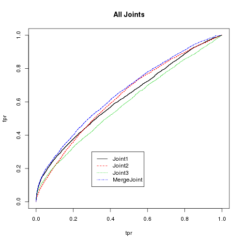

```r
aucMerge <- plotPerformance(allJoints, "All Joints")
```

We can visualize this data in a few different ways.

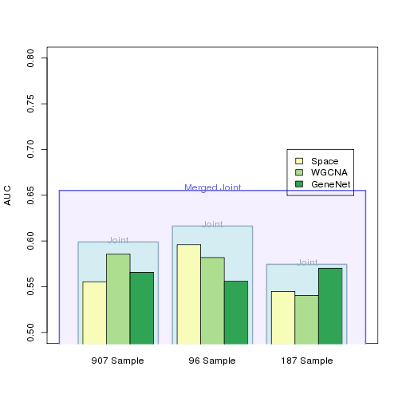

```r
aucs <- t(matrix(as.numeric(rbind(auc1, auc2, auc3)), ncol = length(auc1)))
rownames(aucs) <- c("Space", "WGCNA", "GeneNet", "Joint")
colnames(aucs) <- c("907 Sample", "96 Sample", "187 Sample")

library(RColorBrewer)
mergeCol <- "#6666DD"
mergeBG <- "#F5F0FF"
barCols <- brewer.pal(3, "YlGn")
merges <- "#93ADC3"
mergesFill <- "#D3EDF3"

plot(0, type = "n", xlim = c(0, 13), ylim = c(0.5, 0.8), ylab = "",
    xlab = "", xaxt = "n")

# plot overall merge
polygon(x = c(0, 0, 13, 13), y = c(0, aucMerge[[4]], aucMerge[[4]],
    0), border = mergeCol, lwd = 2, col = mergeBG)
text(6.5, aucMerge[[4]] + 0.002, "Merged Joint", col = mergeCol)

# plot each dataset's joint method
polygon(x = c(0.8, 0.8, 4.2, 4.2), y = c(0, rep(auc1[[4]], 2), 0),
    col = mergesFill, border = merges, lwd = 2)
text(2.5, auc1[[4]] + 0.002, "Joint", col = merges)
polygon(x = c(4.8, 4.8, 8.2, 8.2), y = c(0, rep(auc2[[4]], 2), 0),
    col = mergesFill, border = merges, lwd = 2)
text(6.5, auc2[[4]] + 0.002, "Joint", col = merges)
polygon(x = c(8.8, 8.8, 12.2, 12.2), y = c(0, rep(auc3[[4]], 2),
    0), col = mergesFill, border = merges, lwd = 2)
text(10.5, auc3[[4]] + 0.002, "Joint", col = merges)

barplot(aucs[1:3, ], beside = TRUE, legend = rownames(aucs)[1:3],
    ylab = "AUC", args.legend = list(x = 12.5, y = 0.7), xpd = FALSE, axes = FALSE,
    add = TRUE, col = barCols)
```